# Empleando Futuro

[Gustavo A. García](https://gusgarciacruz.github.io/cv)

[Econometría 2](https://gusgarciacruz.github.io/EconometriaII) - Universidad EAFIT

2024-03

En este ejercicio se va a realizar una aplicación del modelo de Diferencias en Diferencias (DD) para analizar el efecto causal de [Empleando Futuro](https://www.sibs.co/iniciativa/empleado-del-futuro/). Este programa fue el primer [Bono de Impacto Social (BIS)](https://prosperidadsocial.gov.co/sobre-los-bis/) implementado en Colombia y Latinoamérica, y tenía como objetivo fomentar la inserción laboral y retención de la población vulnerable. Empleando Futuro se ejecutó entre marzo de 2017 y diciembre de 2018 en Cali, Pereira y Bogotá. Este ejercicio se basa en el documento de [Chaparro, García y Cardona (2020)](https://www.sibs.co/wp-content/uploads/2023/11/Evaluacion-de-Impacto_Empleando-Futuro_2020.pdf) donde se encuentra más detallada la evaluación de impacto de Empleando Futuro.

Recodemos que modelo de DD es un método estadístico que permite evaluar el efecto causal de una intervención en un grupo de tratamiento en comparación con un grupo de control a lo largo del tiempo. Entre sus ventajas, está el control de factores no observados que podrían incidir tanto en el grupo de tratamiento como en el de control, pero que no guardan una relación directa con el tratamiento en sí, de modo que aborda posibles problemas de selección y endogeneidad al emplear un grupo de control que sea comparable al grupo de tratamiento antes de la intervención. Revisar las slides sobre el tema de DD

### Grupos de tratamiento y control

En la tabla 1 se muestra el esquema de intervención de Empleando Futuro, con los grupos de tratamiento y control seleccionados. El grupo de tratamiento consiste en **1,616** personas que culminaron las etapas de formación e intermediación y que recibieron en total entre 100 y 300 horas de formación. El grupo de control está conformado por **2,795** personas que cumplieron con los criterios de elegibilidad para participar en el programa, pero que no siguieron adelante con el proceso de inscripción (elegibles no inscritos).

Tabla 1. Esquema de intervención de Empleando Futuro, grupo de control y grupo de tratamiento

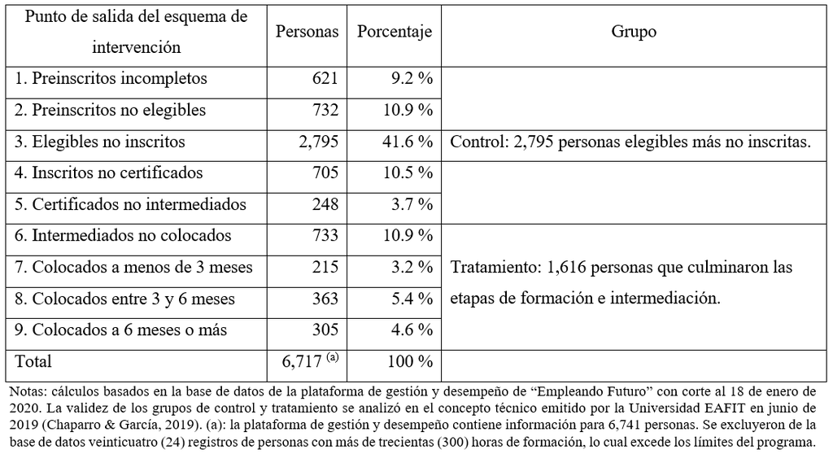

Gráfico 1. Línea de tiempo de Empleando Futuro y el modelo de DD

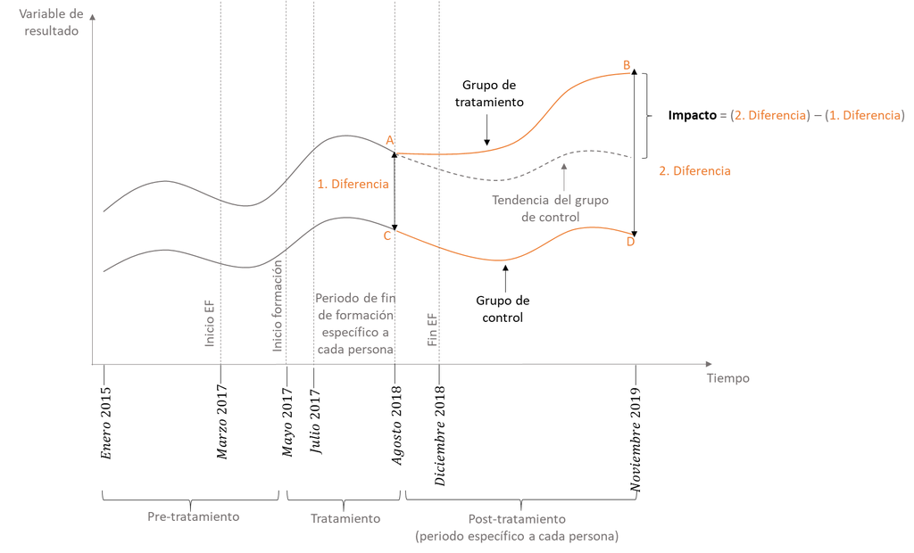

### Datos y creación de variables

En el archivo dataEF_BIS.xlsx se encuntra la información anonimizada de los participantes de Empleando Futuro con las variables de ínteres para este ejercicio. Primero, realizamos los siguientes cambios en la base de datos:

```r
library(haven); library(tidyverse); library(summarytools); library(zoo); library(fastDummies); library(plm); library(lfe)
library(fixest); library(modelsummary); library(broom); library(ggview); library(writexl); library(readxl); library(gt); library(openxlsx)

data <- read.xlsx("https://gusgarciacruz.github.io/EconometriaII/DiD/dataEF_BIS.xlsx") |>
        pivot_longer(cols=starts_with("pila"),
               names_to = "yearmonth",
               names_prefix = "pila",
               values_to = "pila") |>
        mutate(añomes = as.yearmon(yearmonth,"%Y%m"),
               post = case_when(añomes>="sept. 2018" & añomes<="feb. 2020" ~ 1,
                          añomes>="ene. 2015" & añomes<="may. 2017" ~ 0),
               bpila = case_when(pila==1 ~ 1,
                           pila %in% NA ~ 0)) |>
        relocate(id, treat, yearmonth, añomes, post, bpila)
```

### Estimación del modelo de DD

Existen dos especificaciones para estimar el DD, que arrojan los mismos resultados. La primera es la especificación **clásica** donde se interactua la variable de tratamiento con la de postratamiento, esto es:

$$bpila_{it} = \beta_1 + \beta_2
Tratamiento_{i} + \beta_3 Postratamiento_{it} + \beta_4
Tratamiento_{i}*Postratamiento_{it} + \epsilon_{it}$$
Aquí el coeficiente de interés que mide el efecto promedio en los tratados (ATT) es $\beta_4$.

La otra especificación es el **Two-way Fixed Effects** (TWFE) y presenta la siguiente estructura:

$$bpila_{it} = \alpha_i + \gamma_t + \beta
D_{it} + \epsilon_{it}$$
donde $D_{it} = Tratamiento_{i}*Postratamiento_{it}$ y el efecto causal del programa es estimado con $\beta$.

Existen 5 formas de estimar el modelo de DD en R, 2 que estiman el DD clásico y 3 que estiman el TWFE. A continuación se muestra cada una de las funciones utilizadas y los resultados.

```r
dd1 <- lm(bpila ~ treat+post+treat:post, data=data)

dd2 <- lm(bpila ~ treat*post, data=data)

data_panel <- pdata.frame(data, index = c("id", "añomes"))
dd3 <- plm(bpila ~ treat:post,
           data = data_panel, model = "within", effect = "twoways")

dd4 <-felm(bpila ~ treat:post |  id + añomes, data = data)

dd5 <- feols(bpila ~ treat:post | id + añomes, vcov = "iid", data = data)

modelos <- list("OLS1" = dd1,
                "OLS2" = dd2,
                "TWFE1" = dd3,
                "TWFE2" = dd4,
                "TWFE3" = dd5)

modelsummary(modelos,
             output = 'gt',
             coef_map = c('(Intercept)' = 'Intercepto',
                          'treat' = 'Tratamiento',
                          'post' = 'Post',
                          'treat:post' = 'Trat × Post'),
             stars = c('*'=.1, '**'=.05, '***'=.01),
             statistic = "std.error",
             title = 'Tabla 2. Estimaciones del modelo de DD (Y = 1 formal, 0 no formal)',
             gof_omit = 'IC|Log|RMSE',
             notes = "Nota: Errores estándar en paréntesis") |>
             tab_style(style = cell_text(color = 'red'), locations = cells_body(rows = 7))
```

Tabla 2. Estimaciones del modelo de DD (Y = 1 formal, 0 no formal)

|  | OLS1 | OLS2 | TWFE1 | TWFE2 | TWFE3 |
| --- | --- | --- | --- | --- | --- |
| Intercepto | 0.214*** | 0.214*** |  |  |  |
|  | (0.002) | (0.002) |  |  |  |
| Tratamiento | 0.006** | 0.006** |  |  |  |
|  | (0.003) | (0.003) |  |  |  |
| Post | 0.140*** | 0.140*** |  |  |  |
|  | (0.003) | (0.003) |  |  |  |
| Trat × Post | 0.060*** | 0.060*** | 0.060*** | 0.060*** | 0.060*** |
|  | (0.004) | (0.004) | (0.003) | (0.003) | (0.003) |
| Num.Obs. | 207317 | 207317 | 207317 | 207317 | 207317 |
| R2 | 0.033 | 0.033 | 0.001 | 0.342 | 0.342 |
| R2 Adj. | 0.033 | 0.033 | -0.020 | 0.327 | 0.327 |
| R2 Within |  |  |  |  | 0.001 |
| R2 Within Adj. |  |  |  |  | 0.001 |
| F | 2334.278 | 2334.278 |  |  |  |
| Std.Errors |  |  |  |  | IID |
| FE: id |  |  |  |  | X |
| FE: añomes |  |  |  |  | X |

* p < 0.1, ** p < 0.05, *** p < 0.01  
Nota: Errores estándar en paréntesis

Los resultados muestran que el efecto de Empleando Futuro sobre la formalidad es positivo y estadísticamente significativo. En particular, se tiene que en promedio el programa incrementa en 6 puntos porcentuales la probabilidad que una persona se ubique en la formalidad.